# DataSurfers_RPlotDraft

Anuja Janet, Srinivasa Keerthy Vishnubhotla, Molly Witzenburg

November 7, 2017

```r
ghg <- read.csv("https://raw.githubusercontent.com/MBWitz/DataSurfers/master/air_ghg_data_w_regions_new.csv")
```

### Question 1: Which countries and regions contribute the most CO2 emissions, both on a total volume basis and from a per capita perspective? Do the top offenders have similar patterns of increasing and decreasing emissions?

#### Create a subset of just CO2 values:

```r
ghg.sub <- ghg[ghg$SUBJECT == 'CO2', ]
```

#### Create a subset of CO2 set with CO2 that is measured in Millions of Tons:

```r
ghg.sub2 <- ghg.sub[ghg.sub$MEASURE == 'MLN_TONNE', ]
```

#### Create a subset with 7 countries who have been in top five since 1971 (checked ten dates at approximately 5 year intervals between 1971 and 2014 in last week’s R Script):

```r
top7data<- ghg.sub2[ghg.sub2$COUNTRY=="USA"|ghg.sub2$COUNTRY=="CHN"|ghg.sub2$COUNTRY=="DEU"|ghg.sub2$COUNTRY=="RUS"|ghg.sub2$COUNTRY=="IND"|ghg.sub2$COUNTRY=="GBR"|ghg.sub2$COUNTRY=="JPN",]
```

#### Include only CO2 measured since 1971 (because several countries have no data prior)

```r
top7CO2<- top7data[top7data$TIME>=1971, ]
summary(top7CO2)
```

```
##     COUNTRY         INDICATOR   SUBJECT            MEASURE    FREQUENCY
##  CHN    :44   AIREMISSION:289   CO :  0   KG_CAP       :  0   A:289
##  DEU    :44                     CO2:289   MLN_TONNE    :289
##  GBR    :44                     GHG:  0   THND_TONNE   :  0
##  IND    :44                     NOX:  0   THND_TONNECO2:  0
##  JPN    :44                     SOX:  0   TONNE_CAP    :  0
##  USA    :44                     VOC:  0
##  (Other):25
##       TIME          Value        Flag.Codes Lookup.Column.Index
##  Min.   :1971   Min.   : 181.0    :289      Min.   :15.00
##  1st Qu.:1983   1st Qu.: 740.6   B:  0      1st Qu.:27.00
##  Median :1994   Median :1046.0              Median :38.00
##  Mean   :1993   Mean   :1884.0              Mean   :37.32
##  3rd Qu.:2004   3rd Qu.:2019.7              3rd Qu.:48.00
##  Max.   :2014   Max.   :9087.0              Max.   :58.00
##
##  Urbanization.     Population                              Region
##  Min.   :17.18   Min.   :5.590e+07   Northern Europe          :113
##  1st Qu.:34.87   1st Qu.:8.168e+07   Eastern Asia             : 88
##  Median :73.60   Median :1.453e+08   Northern America         : 44
##  Mean   :62.14   Mean   :4.065e+08   Southern Asia            : 44
##  3rd Qu.:78.11   3rd Qu.:7.992e+08   Australia and New Zealand:  0
##  Max.   :93.02   Max.   :1.364e+09   Central America          :  0
##                                      (Other)                  :  0
##    OECD_Flag
##  Min.   :0.0000
##  1st Qu.:0.0000
##  Median :0.0000
##  Mean   :0.4567
##  3rd Qu.:1.0000
##  Max.   :1.0000
##
```

#### Line plots of CO2 emissions in top 7 countries, different color for each country:

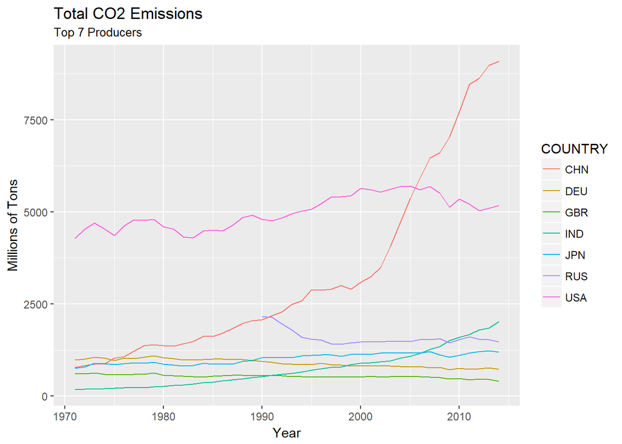

```r
require(ggplot2)
ggplot(data = top7CO2, aes(x = TIME, y = Value, group = COUNTRY)) + xlab("Year") + ylab("Millions of Tons") + ggtitle("Total CO2 Emissions", subtitle="Top 7 Producers") + geom_line(aes(color = COUNTRY))
```

#### Calculate per capita CO2 emissions for top7 and plot them:

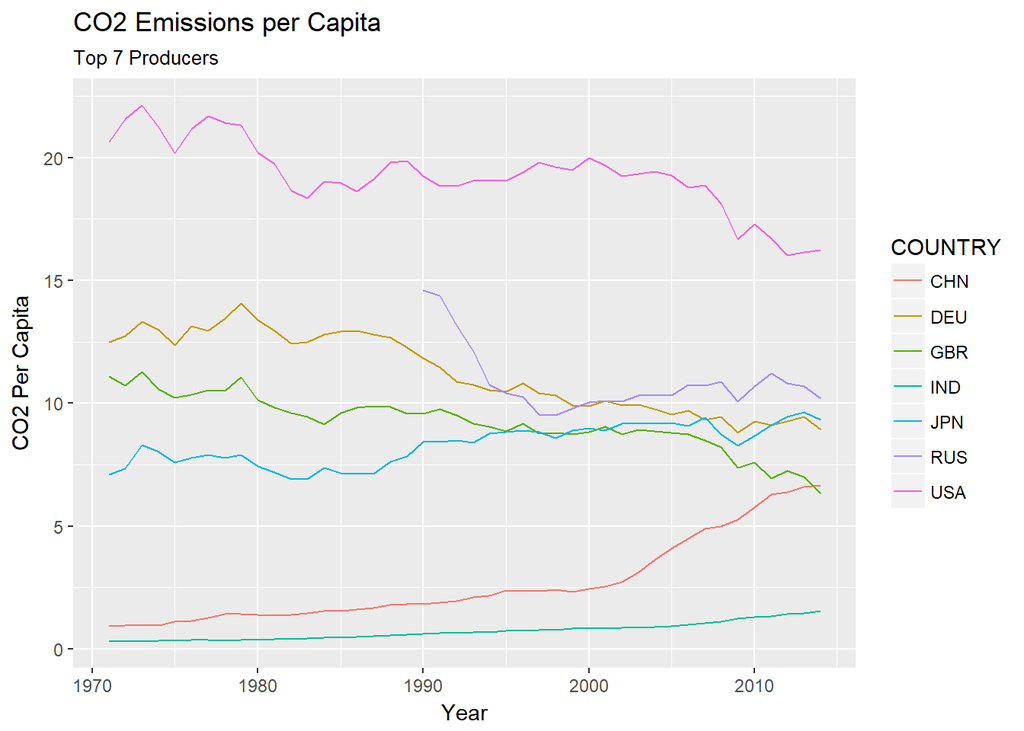

```r
top7CO2$CO2percap <- with(top7CO2, (top7CO2$Value/top7CO2$Population)*1000000)
ggplot(data = top7CO2, aes(x = TIME, y = CO2percap, group = COUNTRY)) +
     xlab("Year") + ylab("CO2 Per Capita") +
     ggtitle("CO2 Emissions per Capita", subtitle="Top 7 Producers") +
     geom_line(aes(color = COUNTRY))
```

When considering per capita CO2 emissions, the USA is consistently significantly higher than any other country of the top 7 CO2 emissions producing countries. The USA, Germany, and Great Britain exhibit decreasing trend over time, while Japan and India are growing slowly, and China grew quite rapidly in the last two decades. Russia has not exhibited a consistent pattern, but their CO2 emissions per capita are consistently among the highest.

#### Summarize CO2 Emissions by Region, eliminating OECD member nation data and World Data:

```r
ghg.sub3<-ghg.sub2[ghg.sub2$COUNTRY!="WLD"&ghg.sub2$COUNTRY!="OED",]
ghg.region<- with(ghg.sub3,(aggregate(list(Population=ghg.sub3$Population,Value=ghg.sub3$Value), by=list(Region=ghg.sub3$Region, TIME=ghg.sub3$TIME), FUN=sum)))
```

#### Calculate per capita emissions by region:

```r
ghg.region$CO2percap <- with(ghg.region, (ghg.region$Value/ghg.region$Population)*1000000)
```

#### Graph CO2 emissions by region and per Capita by region starting in 1971:

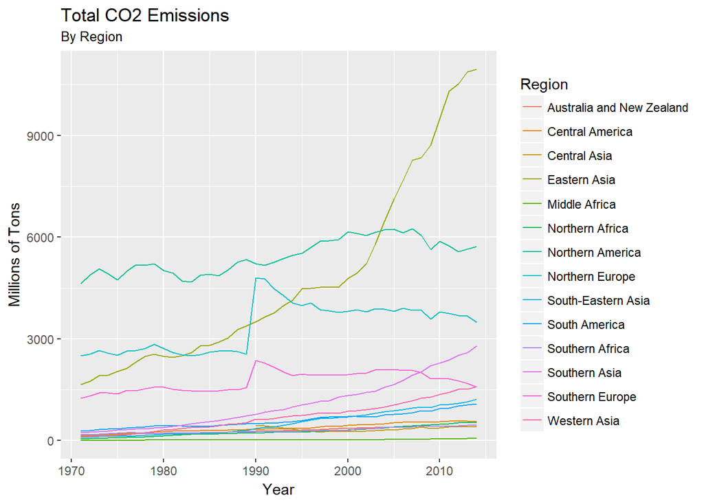

```r
ghg.region<-ghg.region[ghg.region$TIME>=1971,]
ggplot(data = ghg.region, aes(x = TIME, y = Value, group = Region)) +
     xlab("Year") + ylab("Millions of Tons") +
     ggtitle("Total CO2 Emissions", subtitle="By Region") +
     geom_line(aes(color = Region))
```

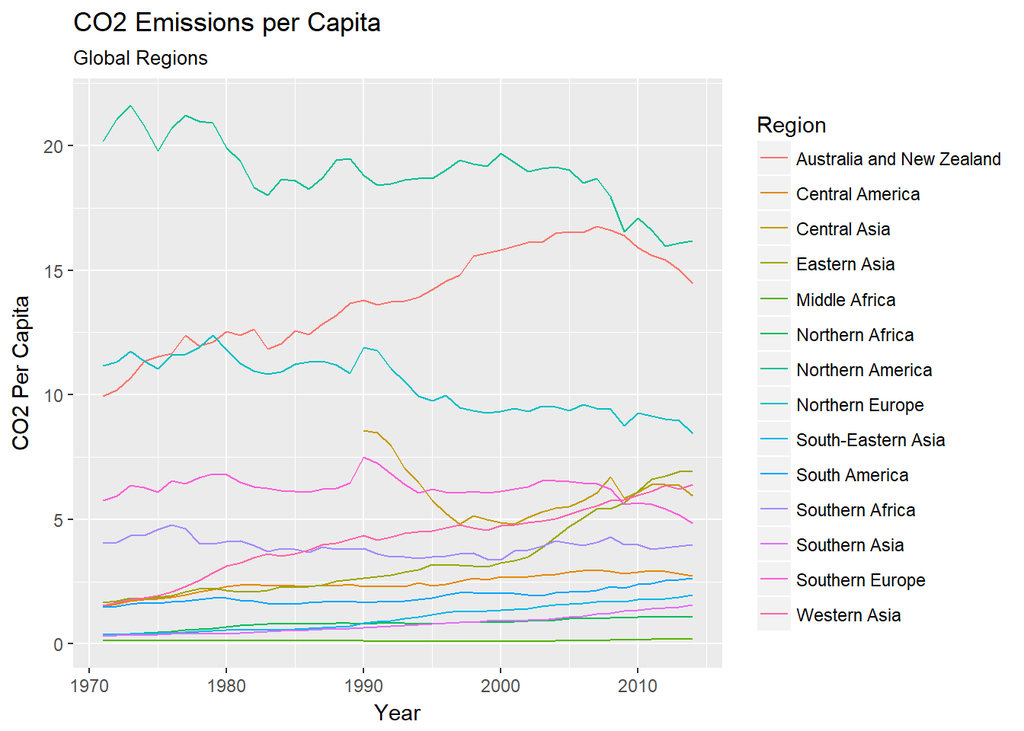

```r
ggplot(data = ghg.region, aes(x = TIME, y = CO2percap, group = Region)) +
     xlab("Year") + ylab("CO2 Per Capita") +
     ggtitle("CO2 Emissions per Capita", subtitle="Global Regions") +
     geom_line(aes(color = Region))
```

### Question 2: Are urbanization rates correlated to carbon dioxide emissions?

#### Create a subset by removing WLD ans OED countries.

```r
ghg.sub3<-subset(ghg.sub2, ghg.sub2$COUNTRY!='WLD' & ghg.sub2$COUNTRY!='OED')
```

#### Summary of the subset.

```r
summary(ghg.sub3)
```

```
##     COUNTRY           INDICATOR    SUBJECT             MEASURE
##  AUS    :  55   AIREMISSION:5737   CO :   0   KG_CAP       :   0
##  AUT    :  55                      CO2:5737   MLN_TONNE    :5737
##  BEL    :  55                      GHG:   0   THND_TONNE   :   0
##  CAN    :  55                      NOX:   0   THND_TONNECO2:   0
##  CHE    :  55                      SOX:   0   TONNE_CAP    :   0
##  DEU    :  55                      VOC:   0
##  (Other):5407
##  FREQUENCY      TIME          Value         Flag.Codes Lookup.Column.Index
##  A:5737    Min.   :1960   Min.   :   0.19    :5737     Min.   : 4.00
##            1st Qu.:1981   1st Qu.:   5.07   B:   0     1st Qu.:25.00
##            Median :1993   Median :  22.84              Median :37.00
##            Mean   :1992   Mean   : 163.92              Mean   :36.24
##            3rd Qu.:2004   3rd Qu.:  86.83              3rd Qu.:48.00
##            Max.   :2014   Max.   :9086.96              Max.   :58.00
##
##  Urbanization.       Population                    Region
##  Min.   :  4.005   Min.   :1.194e+05   Southern Europe: 899
##  1st Qu.: 39.969   1st Qu.:4.111e+06   Northern Europe: 774
##  Median : 58.965   Median :1.003e+07   Western Asia   : 702
##  Mean   : 57.308   Mean   :4.104e+07   Northern Africa: 543
##  3rd Qu.: 75.015   3rd Qu.:3.078e+07   Central America: 528
##  Max.   :100.000   Max.   :1.364e+09   South America  : 440
##                                        (Other)        :1851
##    OECD_Flag
##  Min.   :0.0000
##  1st Qu.:0.0000
##  Median :0.0000
##  Mean   :0.2695
##  3rd Qu.:1.0000
##  Max.   :1.0000
##
```

#### Create a basic scatter plot between Value and Urbanization to understand how they are correlated.

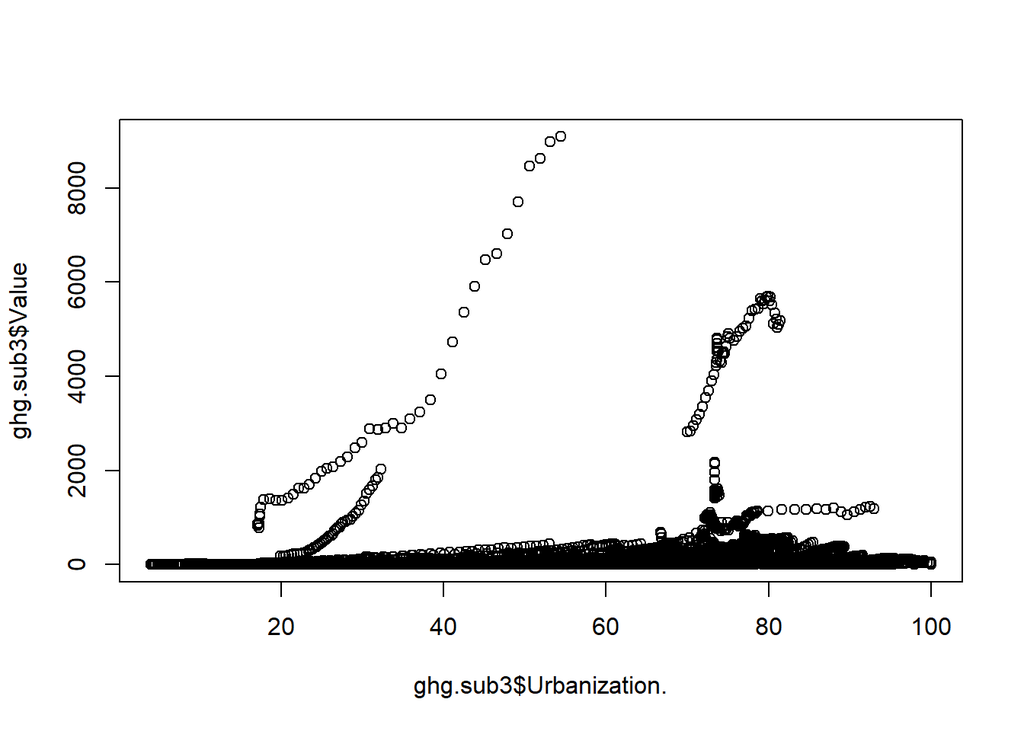

```r
 plot(ghg.sub3$Value~ghg.sub3$Urbanization.)
```

#### Create another subset by removing outliers such as China and USA.

```r
ghg.sub4<-subset(ghg.sub3, ghg.sub3$COUNTRY!='USA' & ghg.sub3$COUNTRY!='CHN')
```

#### Create a scatter plot between value and urbanization with the new subset that we have created.

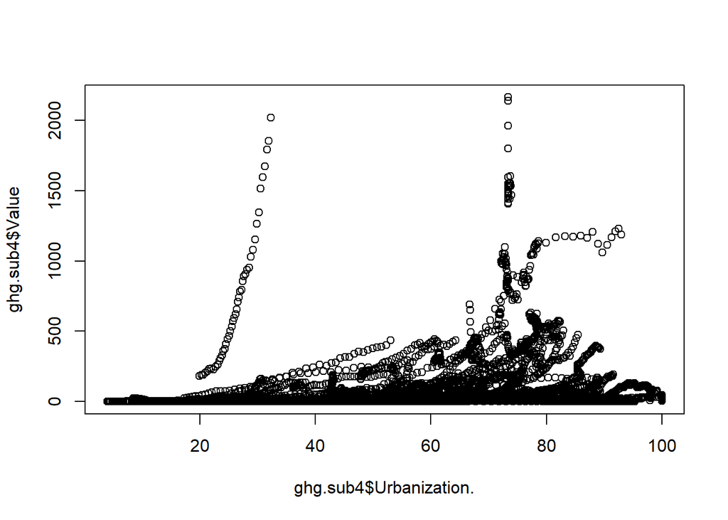

```r
 plot(ghg.sub4$Value~ghg.sub4$Urbanization.)
```

#### A best fit line enables us to understand the positive correlation better.

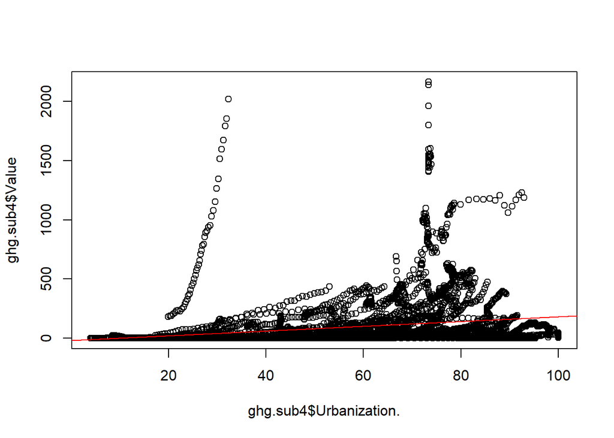

```r
plot(ghg.sub4$Value~ghg.sub4$Urbanization.)
abline(lm(ghg.sub4$Value~ghg.sub4$Urbanization.), col="red")
```

#### Find the correlation value to confirm that it is positive.

```r
cor(ghg.sub4$Value, ghg.sub4$Urbanization) # =.22
```

```
## [1] 0.2208416
```

```r
require(ggplot2)
```

#### Graph CO2 and Urbanization percentage by country, showing different countries in different colors.

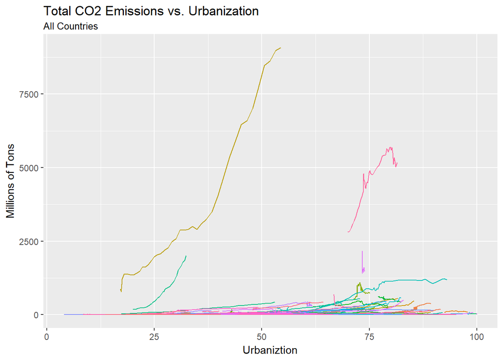

```r
ggplot(data = ghg.sub3, aes(x = Urbanization., y = Value, group = COUNTRY)) +
xlab("Urbaniztion") + ylab("Millions of Tons") + theme(legend.position="none") +
ggtitle("Total CO2 Emissions vs. Urbanization", subtitle="All Countries") +
 geom_line(aes(color = COUNTRY))
```

This plot shows the correlation between Urbanization percentage and CO2 gas emmision with respect to each country including CHINA and USA. The legend was eliminated because there are so many countries, the graph gets too compressed when the legend is displayed.

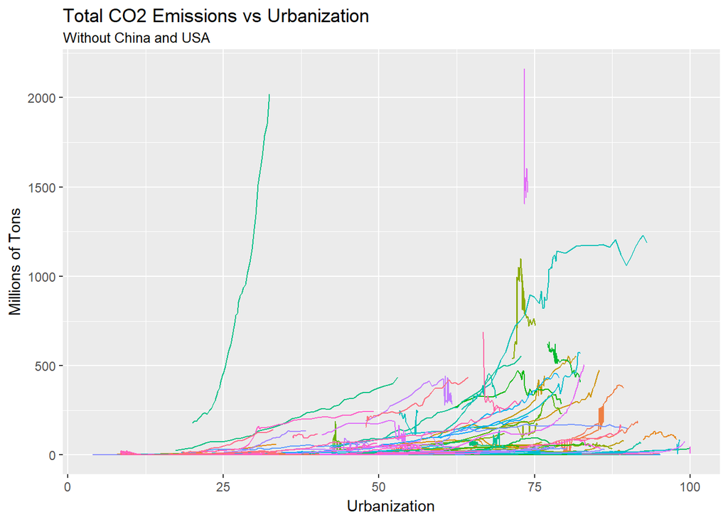

```r
ggplot(data = ghg.sub4, aes(x = Urbanization., y = Value, group = COUNTRY)) +
xlab("Urbanization") + ylab("Millions of Tons") + theme(legend.position="none")+
ggtitle("Total CO2 Emissions vs Urbanization", subtitle="Without China and USA") +
 geom_line(aes(color = COUNTRY))
```

This plot not include CHINA and USA because, while they exhibit the same behavior, their emissions are so much higher than other countries that the graph gets very compressed when they are part of it. This plot makes it easier to visualize the positive correlation between Urbanization and CO2 emissions.

### Question 3: Are Nitrogen Oxides (NOX) and Sulphur Oxides (SOX) emissions highest from OECD (Organization for Economic Cooperation and Development) member countries? Are these emissions correlated to urbanization?

#### Create a subset of just Nitrogen Oxide Emissions data:

```r
nox.sub <- ghg[ghg$SUBJECT == 'NOX', ]
```

#### Create a subset of just Sulphur Oxide emissions data:

```r
nox.sub1 <- ghg[ghg$SUBJECT == 'SOX', ]
```

#### Vertical merging of rows that are having the subject as NOX and SOX

```r
nox_sox<-rbind(nox.sub,nox.sub1)
```

#### Subset the values that are having the measure as ‘THND_TONNE’

```r
nox_sox_tonn <- nox_sox[nox_sox$MEASURE == 'THND_TONNE', ]
```

#### Remove the unnecessary columns

```r
 nox_sox_req<-nox_sox_tonn[,c(1,3,6,7,13)]
```

```r
nox_sox_grouped<-aggregate(nox_sox_req$Value, by=list(TIME=nox_sox_req$TIME,OECD_Flag=nox_sox_req$OECD_Flag), FUN=sum)
```

#### This shows the plot that show variation between OECD and NON-OECD Countries

[figure not shown]

```r
ggplot(data = nox_sox_grouped, aes(x = TIME, y = x, group = OECD_Flag)) +
               xlab("Year") + ylab("Millions of Tons") +
              geom_line(aes(color = OECD_Flag))
```

The plot shows the emmissions of nox and sox gases made by OECD countries to that of non OECD countries from 1990 to 2014. Resultant plot shows decreasing emissions for both Nitrogen Oxide and Sulphur Oxide emissions, with OECD member countries NOX and SOX emissions lower than non-OECD member nations. The main reason for this is that China is in the non-OECD group.